# Loan Club Lending

Manasseh

# 1 Introduction:

Lending club is a leading online marketplace that connects lenders with borrowers for short-term personal loans up to $40,000. They have other offerings as well, but this case study will focus only on personal loans. The company has existed since 2007 and have provided millions of personal loans to individuals. Lending Club announced IPO (Initial Public Offering) in December 2014 since when their business model changed slightly with the company seeming to make risky lending.

Requirements: 1. Study various aspects of lending using R programming. 2. Submit findings in a formal report format. 3. The report must be at least 10 pages long with written description and explanation of your findings to the questions asked below.

#### 1.0.0.1 Data Description:

You are given six years of lending data (2012 – 2017) in csv format. The data files are relatively larger than what you have used during this course so far. The size of each file is different and depends upon the number of loans the company issued in a year. It can be noted that the file size are relatively larger 2015 onward, which is when the company went public and started lending more loans. Each file has 31 columns (variables) and the description of each column is provided in the DataDictionary.xls file.

In addition to that, you are also given the states characteristics in a file called states.csv. This file contains demographic information like population size, median income, unemployment rate etc. Lastly, you are given a regions file called states_regions.csv that contains larger regions and divisions that each state falls in. For example, New Hampshire is in the Northeast region and New England division.

#### 1.0.0.2 Data CodeBook

Column Name Description

1. acc_open_past_24mths - Number of trades opened in past 24 months.
2. addr_state - The state provided by the borrower in the loan application
3. annual_inc - The self-reported annual income provided by the borrower during registration.
4. application_type Indicates whether the loan is an individual application or a joint application with two co-borrowers
5. delinq_2yrs - The number of 30+ days past-due incidences of delinquency in the borrower’s credit file for the past 2 years
6. dti - A ratio calculated using the borrower’s total monthly debt payments on the total debt obligations, excluding mortgage and the requested LC loan, divided by the borrower’s self-reported monthly income.
7. emp_length - Employment length in years. Possible values are between 0 and 10 where 0 means less than one year and 10 means ten or more years.
8. emp_title - The job title supplied by the Borrower when applying for the loan.*
9. grade - LC assigned loan grade
10. home_ownership - The home ownership status provided by the borrower during registration or obtained from the credit report. Our values are: RENT, OWN, MORTGAGE, OTHER
11. inq_last_6mths - The number of inquiries in past 6 months (excluding auto and mortgage inquiries)
12. int_rate - Interest Rate on the loan
13. issue_d - The month which the loan was funded
14. last_credit_pull_d - The most recent month LC pulled credit for this loan
15. last_pymnt_amnt - Last total payment amount received
16. last_pymnt_d - Last month payment was received
17. loan_amnt - The listed amount of the loan applied for by the borrower. If at some point in time, the credit department reduces the loan amount, then it will be reflected in this value.
18. loan_status - Current status of the loan
19. mths_since_last_delinq - The number of months since the borrower’s last delinquency.
20. open_acc - The number of open credit lines in the borrower’s credit file.
21. pub_rec_bankruptcies - Number of public record bankruptcies
22. purpose - A category provided by the borrower for the loan request.
23. sub_grade - LC assigned loan subgrade
24. term - The number of payments on the loan. Values are in months and can be either 36 or 60.
25. title - The loan title provided by the borrower
26. tot_cur_bal - Total current balance of all accounts
27. total_pymnt - Payments received to date for total amount funded
28. total_rec_int - Interest received to date

#### 1.0.0.3 Necessary libraries

```r
library(dplyr)
library(tidyverse)
library(magrittr)
library(ggplot2)
library(stringr)
library(lubridate)
library(caret)
library(rpart)
library(rpart.plot)
library(randomForest)
library(RPostgreSQL)
library(DBI)
library(corrplot)
library(e1071)
library(xgboost)
library(tm)
library(rms)
library(glmnet)
library(pROC)
library(kernlab)
```

# 2 Merging and Cleaning

```r
data2012 = read.csv("data2012.csv")
data2013 = read.csv("data2013.csv")
data2014 = read.csv("data2014.csv")
data2015 = read.csv("data2015.csv")
data2016 = read.csv("data2016.csv")
data2017 = read.csv("data2017.csv")
```

Importing all the six Lending Club files in R-working environment.

### 2.0.1 Stack and Merge data

```r
States = read.csv("States.csv")
states_regions = read.csv("states_regions.csv")
Stregion = merge(States, states_regions, by.x = 'Geography', by.y = 'State')
Combined.Data = rbind(data2012, data2013, data2014, data2015, data2016, data2017)
Merged.Data = merge(Combined.Data,Stregion, by.x ="addr_state", by.y = "State.Code")
```

Importing states and states region files in R-working environment. After the importation of the necessary files in R, Stacking procedure was performed whereby, all the six Lending Club files were stacked together on top of each other using rbind() function. The states file was merged with states region file using state name as the primary key. Finally, the merge file was then joined to the combined file so that to have a complete one large file containing lending club and states geographic and demographic information.

# 3 Analysis

Q1) Find the distribution of number of loans by state, regions and divisions. Describe in your own words the geographic differences in the number of loans are. Also, analyze your results by comparing number of loans per capita. Did you notice any missing states in the Lending Club data? If yes, then find out why.

Number of Loans by State, Region and Division

```r
Q1 = Merged.Data %>%
  group_by(Geography, Region, Division) %>%
  summarise(num_loans = n()) %>%
  arrange(desc(num_loans))
Q1
```

```
## # A tibble: 51 x 4
## # Groups:   Geography, Region [51]
##    Geography    Region    Division           num_loans
##    <chr>        <chr>     <chr>                  <int>
##  1 California   West      Pacific               189070
##  2 New York     Northeast Middle Atlantic       111514
##  3 Texas        South     West South Central    110099
##  4 Florida      South     South Atlantic         93591
##  5 Illinois     Midwest   East North Central     54329
##  6 New Jersey   Northeast Middle Atlantic        49359
##  7 Pennsylvania Northeast Middle Atlantic        46572
##  8 Ohio         Midwest   East North Central     44772
##  9 Georgia      South     South Atlantic         43532
## 10 Virginia     South     South Atlantic         38396
## # ... with 41 more rows
```

California, New York, Texas, and Florida were the states where huge or highest amount of loans were provided while the least amount of loans were provided in North Dakota, Idaho, and Iowa.

Number of Loans and Loans per Capita

```r
Q1.1 = Merged.Data %>%
  group_by(Geography)%>%
  summarise(num_loans = n(),tot_population = mean(population))%>%
  mutate(Loans_per_capita = (num_loans/tot_population)*100000) %>%
 arrange(desc(Loans_per_capita,tot_population))
Q1.1
```

```
## # A tibble: 51 x 4
##    Geography            num_loans tot_population Loans_per_capita
##    <chr>                    <int>          <dbl>            <dbl>
##  1 Nevada                   19134        2887725             663.
##  2 Connecticut              21066        3594478             586.
##  3 New York                111514       19798228             563.
##  4 Rhode Island              5872        1056138             556.
##  5 New Jersey               49359        8960161             551.
##  6 Maryland                 31998        5996079             534.
##  7 Colorado                 28556        5436519             525.
##  8 New Hampshire             6659        1331848             500.
##  9 Wyoming                   2896         583200             497.
## 10 District of Columbia      3317         672391             493.
## # ... with 41 more rows
```

Missing States

```r
States_missing = anti_join(states_regions, Merged.Data, by = c('State'='addr_state'))
States_missing
```

```
##                   State State.Code    Region           Division
## 1                Alaska         AK      West            Pacific
## 2               Alabama         AL     South East South Central
## 3              Arkansas         AR     South West South Central
## 4               Arizona         AZ      West           Mountain
## 5            California         CA      West            Pacific
## 6              Colorado         CO      West           Mountain
## 7           Connecticut         CT Northeast        New England
## 8  District of Columbia         DC     South     South Atlantic
## 9              Delaware         DE     South     South Atlantic
## 10              Florida         FL     South     South Atlantic
## 11              Georgia         GA     South     South Atlantic
## 12               Hawaii         HI      West            Pacific
## 13                 Iowa         IA   Midwest West North Central
## 14                Idaho         ID      West           Mountain
```

[output cut: 37 more lines]

```r
Merged.Data %>%
  filter(addr_state == 'PR')
```

```
##  [1] addr_state
##  [2] loan_amnt
##  [3] term
##  [4] int_rate
##  [5] grade
##  [6] sub_grade
##  [7] emp_title
##  [8] emp_length
##  [9] home_ownership
## [10] annual_inc
## [11] issue_d
## [12] loan_status
## [13] purpose
## [14] title
## [15] dti
```

[output cut: 27 more lines]

Q2) Compare the average amount of loans granted by all states and divisions. Which states and divisions have the highest and lowest average loan amounts?

```r
Compare_Loan = Merged.Data %>%
  group_by(Geography, Division) %>%
  summarise(Avg_Amt_Loans = mean(loan_amnt)) %>%
  arrange(desc(Avg_Amt_Loans))

Compare_Loan
```

```
## # A tibble: 51 x 3
## # Groups:   Geography [51]
##    Geography            Division           Avg_Amt_Loans
##    <chr>                <chr>                      <dbl>
##  1 Alaska               Pacific                   17013.
##  2 Virginia             South Atlantic            15999.
##  3 Massachusetts        New England               15787.
##  4 New Jersey           Middle Atlantic           15742.
##  5 Maryland             South Atlantic            15721.
##  6 Texas                West South Central        15663.
##  7 District of Columbia South Atlantic            15654.
##  8 Wyoming              Mountain                  15569.
##  9 Hawaii               Pacific                   15530.
## 10 Illinois             East North Central        15386.
## # ... with 41 more rows
```

Alaska in Pacific division had the highest average loan amounts followed by Virginia, Massachusetts, New Jersey, and Maryland.

Group by state and division, calculate average amount of loans

```r
lower.2 = Merged.Data %>%
  group_by(Geography, Division) %>%
  summarise(Avg_Amt_Loans = mean(loan_amnt)) %>%
  arrange(Avg_Amt_Loans)
lower.2
```

```
## # A tibble: 51 x 3
## # Groups:   Geography [51]
##    Geography    Division           Avg_Amt_Loans
##    <chr>        <chr>                      <dbl>
##  1 Iowa         West North Central         6962.
##  2 Montana      Mountain                  13679.
##  3 Vermont      New England               13818.
##  4 South Dakota West North Central        13934.
##  5 Oregon       Pacific                   13946.
##  6 Arkansas     West South Central        13968.
##  7 Nebraska     West North Central        13980.
##  8 Idaho        Mountain                  14020.
##  9 Nevada       Mountain                  14112.
## 10 Florida      South Atlantic            14186.
## # ... with 41 more rows
```

Iowa State had the lowest average loan amounts located in the West North Central division.

Group by division, calculate average amount of loans

```r
lower.3 = Merged.Data %>%
  group_by(Division) %>%
  summarise(Avg_Amt_Loans = mean(loan_amnt)) %>%
  arrange(Avg_Amt_Loans)
lower.3
```

```
## # A tibble: 9 x 2
##   Division           Avg_Amt_Loans
##   <chr>                      <dbl>
## 1 West North Central        14487.
## 2 East South Central        14564.
## 3 Mountain                  14569.
## 4 East North Central        14654.
## 5 South Atlantic            14928.
## 6 Middle Atlantic           14955.
## 7 Pacific                   15023.
## 8 New England               15246.
## 9 West South Central        15401.
```

West North Central, East South Central, and Mountain had the lowest average loan amounts.

Q3) Compare the average interest rate charged and average loan amount by the loan Grade. Do you notice any patterns?

Creating a new variable

```r
Merged.Data = Merged.Data %>%
  mutate(int_rate = as.numeric(sub("%","", Merged.Data$int_rate))/100)
```

Group by grade, calculate average amount of loans and average interest

```r
Q3 = Merged.Data %>%
  group_by(grade) %>%
  summarise(Avg_int = mean(int_rate), Avg_loan = mean(loan_amnt)) %>%
  arrange(grade)
Q3
```

```
## # A tibble: 7 x 3
##   grade Avg_int Avg_loan
##   <chr>   <dbl>    <dbl>
## 1 A      0.0710   14308.
## 2 B      0.107    13805.
## 3 C      0.141    14885.
## 4 D      0.177    15654.
## 5 E      0.211    17846.
## 6 F      0.251    19138.
## 7 G      0.281    20758.
```

Q4) Run a frequency distribution of number of loans, average loan amount and average interest rate for each state by year (2012 through 2017). Describe the changing patterns in those numbers.

```r
Q4 = Merged.Data  %>%
  group_by(issue_Year) %>%
  summarise(num_loans=n(), Avg_loan = mean(loan_amnt), Avg_int = mean(int_rate))  %>%
  arrange(issue_Year)
Q4
```

[output not shown]

Q5) Is there a relationship with the population size of a state and the average loan amount given? Is there a relationship between Grade of loans and median income level in a state?

```r
Q5.1 = Merged.Data %>%
  group_by(Geography)%>%
  summarise(num_loans = n(), Avg_loan = mean(loan_amnt), tot_population = mean(population))%>%
 arrange(desc(tot_population))
Q5.1
```

```
## # A tibble: 51 x 4
##    Geography      num_loans Avg_loan tot_population
##    <chr>              <int>    <dbl>          <dbl>
##  1 California        189070   15045.       38982847
##  2 Texas             110099   15663.       27419612
##  3 Florida            93591   14186.       20278447
##  4 New York          111514   14734.       19798228
##  5 Illinois           54329   15386.       12854526
##  6 Pennsylvania       46572   14650.       12790505
##  7 Ohio               44772   14264.       11609756
##  8 Georgia            43532   15155.       10201635
##  9 North Carolina     37586   14690.       10052564
## 10 Michigan           35233   14247.        9925568
## # ... with 41 more rows
```

```r
Q5.2 = Merged.Data %>%
  group_by(grade)%>%
  summarise(median_income = mean(Median_income_Households))%>%
 arrange(desc(median_income))
Q5.2
```

```
## # A tibble: 7 x 2
##   grade median_income
##   <chr>         <dbl>
## 1 A            60268.
## 2 B            59989.
## 3 G            59910.
## 4 F            59896.
## 5 C            59829.
## 6 D            59745.
## 7 E            59729.
```

Borrowers who qualify under Grade A and Grade B have a slightly higher median income as compared to the other loan grade score. The highest median income household receives the highest loan grade level. This imply that the average interest rate on these loans are relatively lower than the median income in grade E.

Q6) This is an open-ended question where you are asked to share an interesting fact that you found through data analysis.

```r
Q6 = Merged.Data %>%
  group_by(emp_length)%>%
  summarise(avg_loan_amount = mean(loan_amnt))%>%
 arrange(desc(avg_loan_amount))
Q6
```

```
## # A tibble: 12 x 2
##    emp_length  avg_loan_amount
##    <chr>                 <dbl>
##  1 "10+ years"          16100.
##  2 "9 years"            15333.
##  3 "8 years"            15118.
##  4 "7 years"            14977.
##  5 "< 1 year"           14809.
##  6 "6 years"            14766.
##  7 "5 years"            14579.
##  8 "4 years"            14433.
##  9 "3 years"            14284.
## 10 "2 years"            14212.
## 11 "1 year"             13952.
## 12 ""                   11865.
```

The relationship between average loan amount and employment length show that people with longer employment length have the highest average loan amount. This implies that borrowers who have been employed for longer years stand at a better chance of accessing higher loan amounts.

# 4 Visualization

Q1) Create a plot of interest rates and Grade or a loan and describe the pattern.

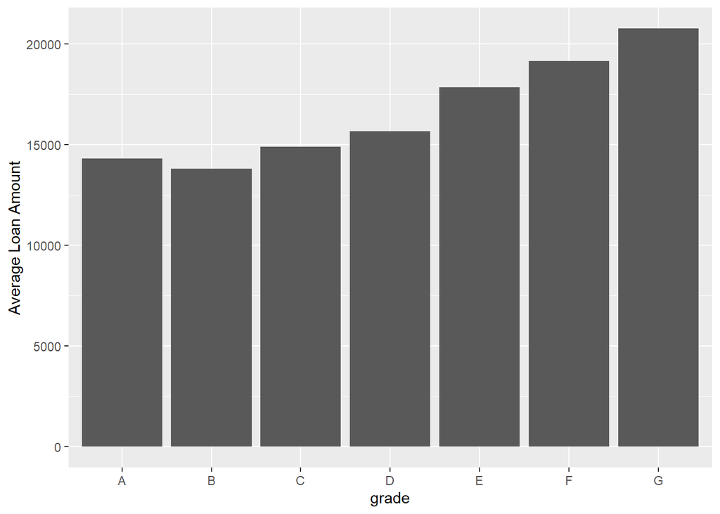

```r
Merged.Data %>%
  group_by(grade)%>%
  summarise(avg_loan_amnt = mean(loan_amnt))%>%
ggplot(aes(x = grade, y = avg_loan_amnt)) +
    geom_bar(stat = "identity") +
  ylab("Average Loan Amount")
```

The bar plot of average loan amount and grade show that good borrowers have lesser average loan amount and bad borrowers have a higher average loan amount. This is quite interesting as good borrowers should be the ones be having huge loan amount because they have lower risks.

Q2) Create a map of US states and color code the map with the average amount of loans given.

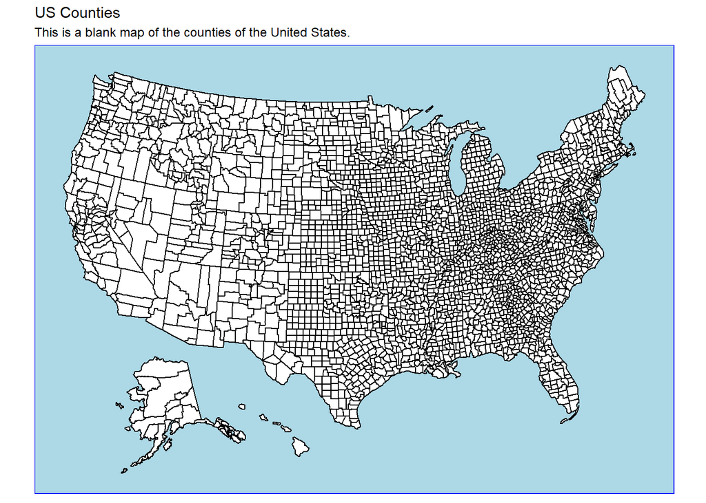

```r
library(usmap)
library(ggplot2)

plot_usmap(regions = "counties") +
  labs(title = "US Counties",
       subtitle = "This is a blank map of the counties of the United States.") +
  theme(panel.background = element_rect(color = "blue", fill = "lightblue"))
```

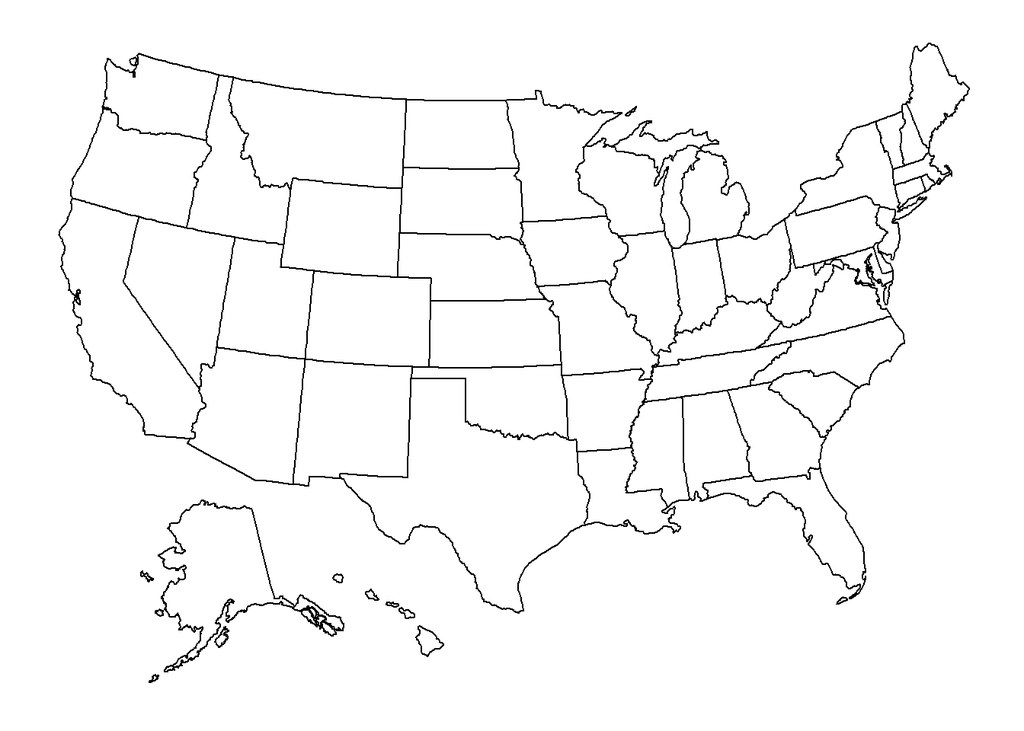

```r
plot_usmap()
```

```r
AverLoanAmt = Merged.Data %>%
  group_by(Geography)%>%
  summarise(num_loans = n(), avg_loan_amnt = mean(loan_amnt))
AverLoanAmt$fips = fips(AverLoanAmt$Geography)
dplyr::sample_n(AverLoanAmt, 5)
```

```
## # A tibble: 5 x 4
##   Geography    num_loans avg_loan_amnt fips
##   <chr>            <int>         <dbl> <chr>
## 1 Virginia         38396        15999. 51
## 2 Wyoming           2896        15569. 56
## 3 Nevada           19134        14112. 32
## 4 North Dakota      1660        14960. 38
## 5 South Dakota      2743        13934. 46
```

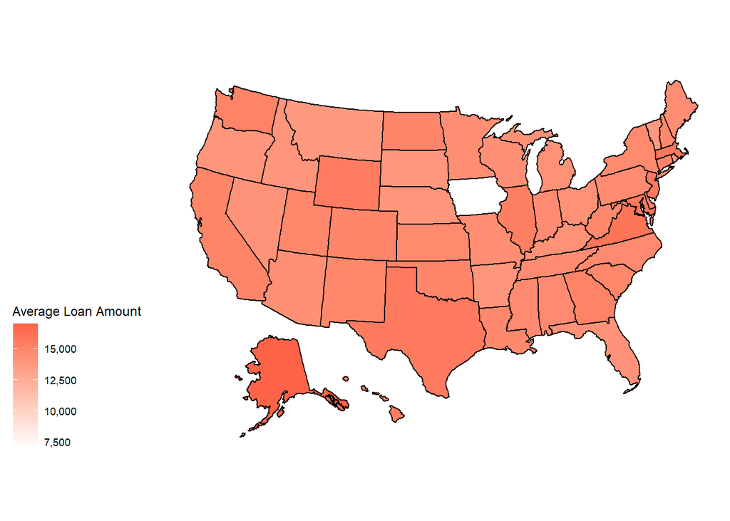

```r
plot_usmap(data = AverLoanAmt, values = "avg_loan_amnt", color = "black") +
  scale_fill_continuous(
    low = "white", high = "tomato", name = "Average Loan Amount", label = scales::comma
  ) + theme(legend.position = "left")
```

Q3) Show visually the relationship between the annual income of the recipient and the loan amount obtained from Lending Club.

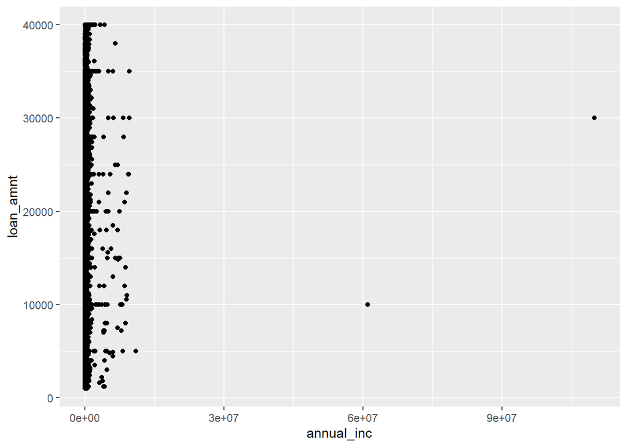

```r
ggplot(data = Merged.Data) +
  geom_point(mapping = aes(x = annual_inc, y = loan_amnt))
```

Q4) Create a plot that shows the relationship between the length of employment and amount of loan obtained.

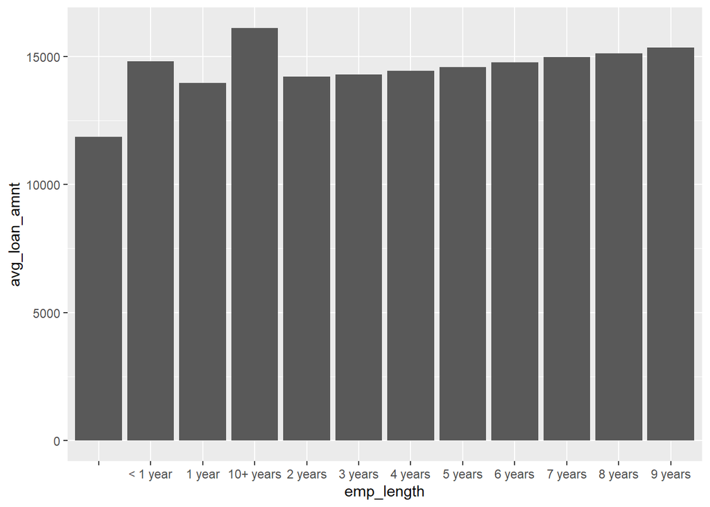

```r
Merged.Data %>%
  group_by(emp_length)%>%
  summarise(avg_loan_amnt = mean(loan_amnt))%>%
ggplot(aes(x = emp_length, y = avg_loan_amnt)) +
    geom_bar(stat = "identity")
```

Q5) Create a “regional” map and show an interesting relationship of your liking.

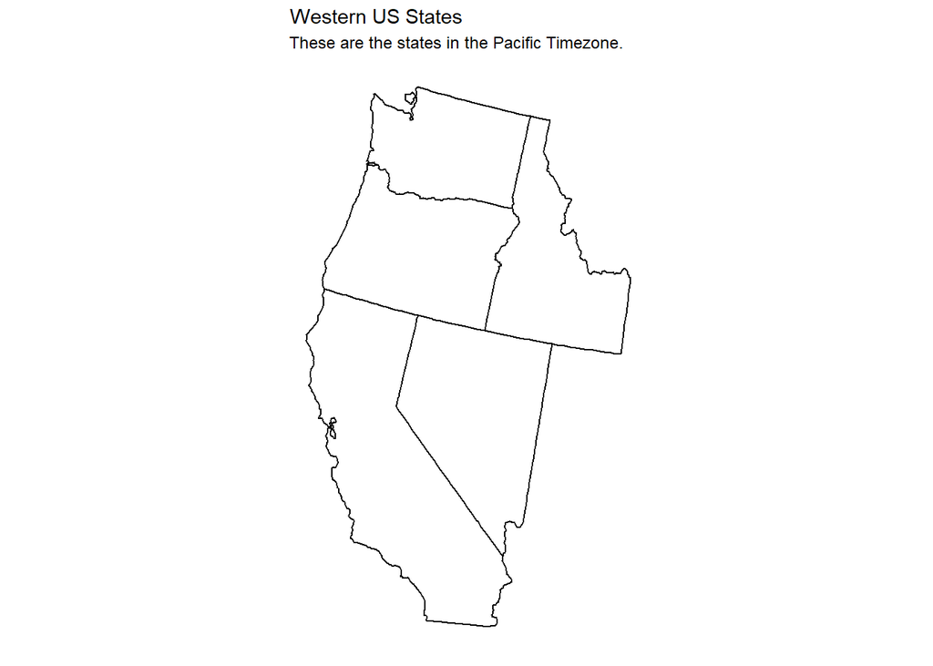

```r
plot_usmap(include = c("CA", "ID", "NV", "OR", "WA")) +
  labs(title = "Western US States",
       subtitle = "These are the states in the Pacific Timezone.")
```

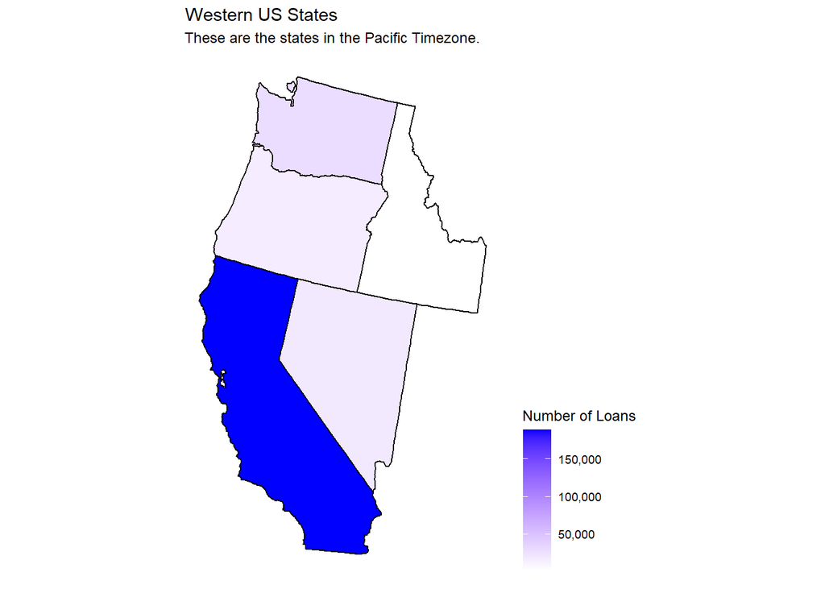

```r
plot_usmap(
    data = AverLoanAmt, values = "num_loans", include = c("CA", "ID", "NV", "OR", "WA"), color = "black"
  ) +
  scale_fill_continuous(
    low = "white", high = "blue", name = "Number of Loans", label = scales::comma
  ) +
  labs(title = "Western US States", subtitle = "These are the states in the Pacific Timezone.") +
  theme(legend.position = "right")
```